# Bad Habits and Health

Indagare interrelazione tra bad habits: fumare, bere, dormire poco, poco allenamento poche verdure

Indagare la relazione tra depressione, insonnia, e le altre cose brutte

Indagare la relazione tre le bad habits e le cose brutte

```r
library(devtools)
install_github("StatsWithR/statsr")
```

```
## Skipping install of 'statsr' from a github remote, the SHA1 (6f64cf27) has not changed since last install.
##   Use `force = TRUE` to force installation
```

```r
library(dplyr)
```

```r
library(statsr)
library(ggplot2)
library(grid)
library(gridExtra)
load("brfss2013.RData")
```

```r
#function to compute the drinksper day
drinks_per_day <- function(alcday, avedrnk, drinker) {
  output <- ifelse(alcday < 200, (alcday - 100)*avedrnk/7,
   (alcday - 200)*avedrnk/30)
  return(output)
}
```

```r
brfss2013 <- brfss2013 %>%
   mutate(drinker = ifelse((alcday5 > 100) & (alcday5 < 231), "Yes", "No"))
brfss2013 <- brfss2013 %>%
   mutate(drnk_perdy = ifelse(drinker == "No", 0, drinks_per_day(alcday5, avedrnk2, drinker)))
```

```r
brfss2013 %>%
   group_by(drinker) %>%
   summarise(count = n())
```

```
## # A tibble: 3 x 2
##   drinker  count
##     <chr>  <int>
## 1      No 236719
## 2     Yes 235412
## 3    <NA>  19644
```

```r
brfss2013 %>%
  group_by(drinker) %>%
  filter(!is.na(drnk_perdy)) %>%
  summarise(drinks = mean(drnk_perdy))
```

```
## # A tibble: 2 x 2
##   drinker    drinks
##     <chr>     <dbl>
## 1      No 0.0000000
## 2     Yes 0.7554214
```

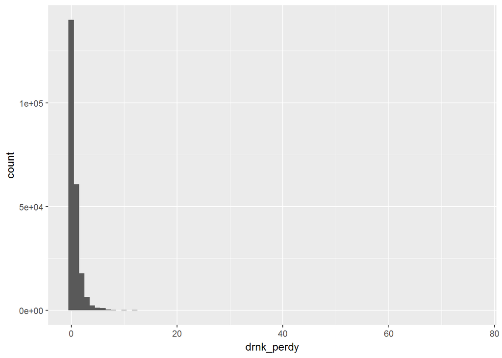

```r
brfss2013 %>%
  filter(drinker == "Yes") %>%
  ggplot(aes(x = drnk_perdy)) +
  geom_histogram(binwidth = 1)
```

```r
brfss2013 <- brfss2013 %>%
  mutate(rsk_drnk = ifelse((drnk_perdy > 2), "Yes", "No"))

Total_drinkers <- brfss2013 %>%
   filter(drinker == "Yes") %>%
   nrow()
brfss2013 %>%
  filter(drinker == "Yes") %>%
  group_by(rsk_drnk) %>%
  summarise(count = n()/Total_drinkers)
```

```
## # A tibble: 3 x 2
##   rsk_drnk      count
##      <chr>      <dbl>
## 1       No 0.91802032
## 2      Yes 0.06399844
## 3     <NA> 0.01798124
```

The variable `drnk_perdy`is skewed on the right and accumulates at `0`, so we take its logarithm

```r
brfss2013 <- brfss2013 %>%
  mutate(drnk_perdy_ln = log1p(drnk_perdy))
summary(brfss2013$drnk_perdy_ln)
```

```
##    Min. 1st Qu.  Median    Mean 3rd Qu.    Max.    NA's
##   0.000   0.000   0.000   0.214   0.262   4.344   23877
```

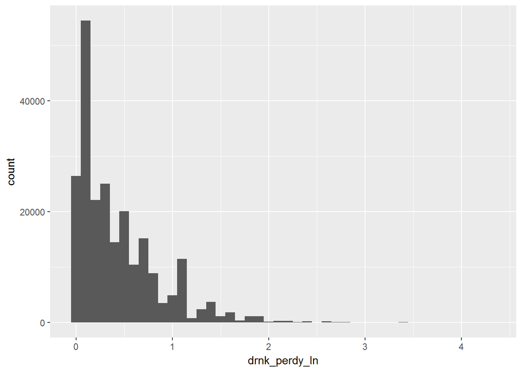

```r
brfss2013 %>%
  filter(!is.na(drnk_perdy_ln) & (drnk_perdy_ln>0)) %>%
  ggplot( aes(x=drnk_perdy_ln)) +
  geom_histogram(binwidth = 0.1)
```

```r
brfss2013 <- brfss2013 %>%
  mutate(smoker = ifelse((smokday2 == "Every day") |(smokday2 == "Some days"), "Yes", "No"))
```

```r
Total_obsv <- brfss2013 %>%
   nrow()
brfss2013 %>%
  group_by(smoker) %>%
  summarise(count = n()/Total_obsv)
```

```
## # A tibble: 3 x 2
##   smoker     count
##    <chr>     <dbl>
## 1     No 0.2808907
## 2    Yes 0.1558782
## 3   <NA> 0.5632312
```

```r
summary(brfss2013$sleptim1)
```

```
##    Min. 1st Qu.  Median    Mean 3rd Qu.    Max.    NA's
##   0.000   6.000   7.000   7.052   8.000 450.000    7387
```

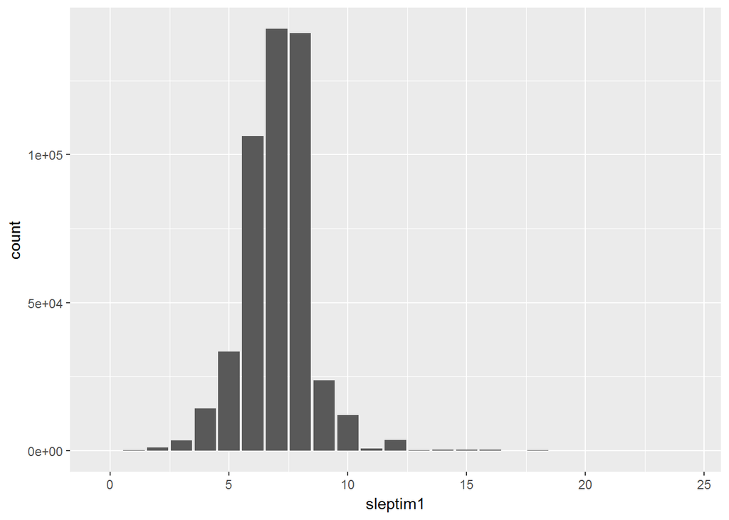

```r
brfss2013 %>%
  filter(!is.na(sleptim1) & (sleptim1 < 25)) %>%
  ggplot(aes(x= sleptim1)) +
  geom_bar()
```

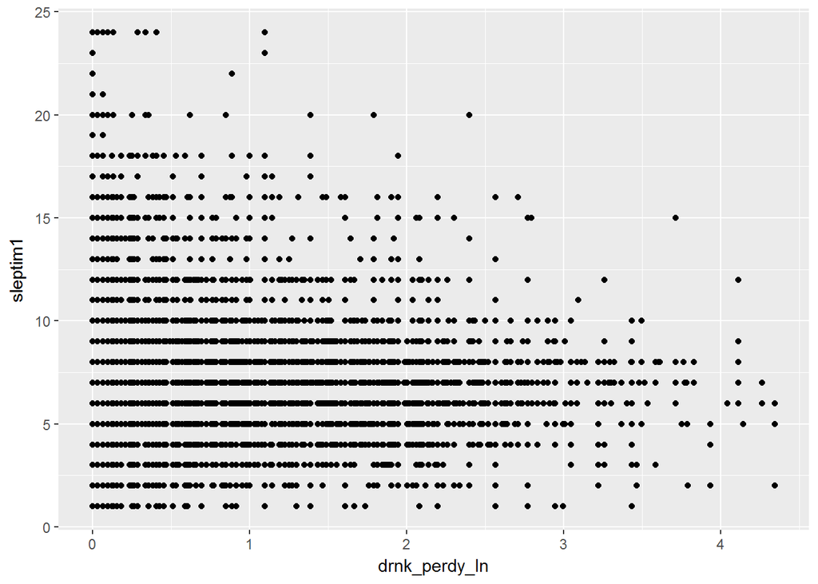

```r
brfss2013 %>%
  filter(!is.na(sleptim1) & !is.na(drnk_perdy_ln)) %>%
  ggplot(aes(x = drnk_perdy_ln, y = sleptim1)) + geom_point()
```

Not very meaningful.

```r
brfss2013 %>%
  filter(!is.na(sleptim1)) %>%
  group_by(rsk_drnk, smoker) %>%
  summarise(average_slept_hours = mean(sleptim1), std_slpt_hrs = sd(sleptim1))
```

```
## # A tibble: 9 x 4
## # Groups:   rsk_drnk [?]
##   rsk_drnk smoker average_slept_hours std_slpt_hrs
##      <chr>  <chr>               <dbl>        <dbl>
## 1       No     No            7.118463     1.441385
## 2       No    Yes            6.783097     1.711634
## 3       No   <NA>            7.090337     1.380249
## 4      Yes     No            7.183813     1.423522
## 5      Yes    Yes            6.814311     1.699653
## 6      Yes   <NA>            7.001858     1.397520
## 7     <NA>     No            7.202903     1.583369
## 8     <NA>    Yes            6.838710     2.738758
## 9     <NA>   <NA>            7.107788     3.690724
```

Contrary to what I was expecting, smoking and drinking do not influence too much the avarage number of hours slept.

## Vegetables

```r
# to be used with fvgreen, fvorange and vegetab1
veg_per_day <- function(fveg) {
  output <- ifelse((fveg > 100) & (fveg < 200), (fveg - 100),
              ifelse((fveg > 200) & (fveg < 300), (fveg - 200)/7,
                ifelse((fveg > 300) & (fveg < 400), (fveg - 300)/30, 0)))
  return(output)
}
```

We are interested on the times per day someone eates vegetables. In order to get this number we start from `fvgreen`, `fvorange` and `vegetab1` and we count them together to have an overall amount. We store this in `veg_perdy`

```r
brfss2013 <- brfss2013 %>%
  mutate(veg_perdy = veg_per_day(fvgreen) + veg_per_day(fvorang) +veg_per_day(vegetab1))
summary(brfss2013$veg_perdy)
```

```
##    Min. 1st Qu.  Median    Mean 3rd Qu.    Max.    NA's
##    0.00    0.87    1.43    1.65    2.14  198.14   44766
```

There are some unrealistic result. For this reason we will filter as NA’s result with more then 20 portions of vegetables a day.

```r
brfss2013 <- brfss2013 %>%
  mutate(veg_perdy = ifelse(veg_perdy > 20, NA, veg_perdy))
summary(brfss2013$veg_perdy)
```

```
##    Min. 1st Qu.  Median    Mean 3rd Qu.    Max.    NA's
##    0.00    0.87    1.43    1.64    2.14   20.00   44833
```

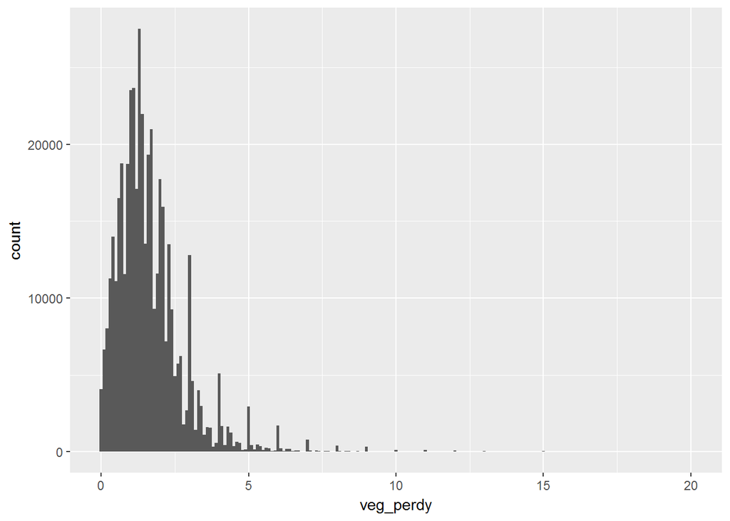

```r
brfss2013 %>%
  ggplot(aes(x = veg_perdy)) +geom_histogram(binwidth = 0.1)
```

Also vegetable consumption seems right skewed. We therfore take the logarithm of it

```r
brfss2013 <- brfss2013 %>%
  mutate(veg_perdy_ln = log1p(veg_perdy))
summary(brfss2013$veg_perdy_ln)
```

```
##    Min. 1st Qu.  Median    Mean 3rd Qu.    Max.    NA's
##    0.00    0.62    0.89    0.89    1.15    3.04   44833
```

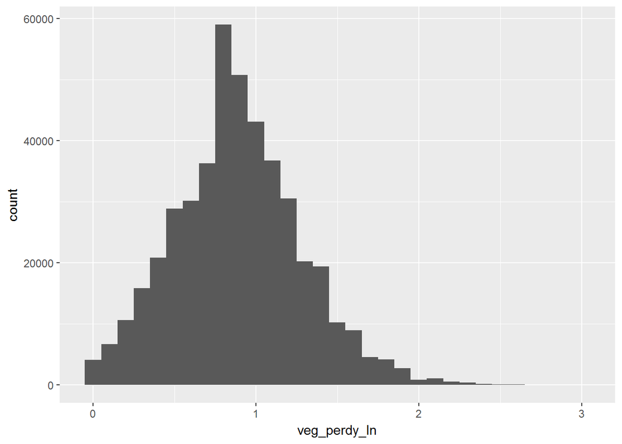

```r
brfss2013 %>%
  filter(!is.na(veg_perdy_ln)) %>%
  ggplot( aes(x=veg_perdy_ln)) +
  geom_histogram(binwidth = 0.1)
```

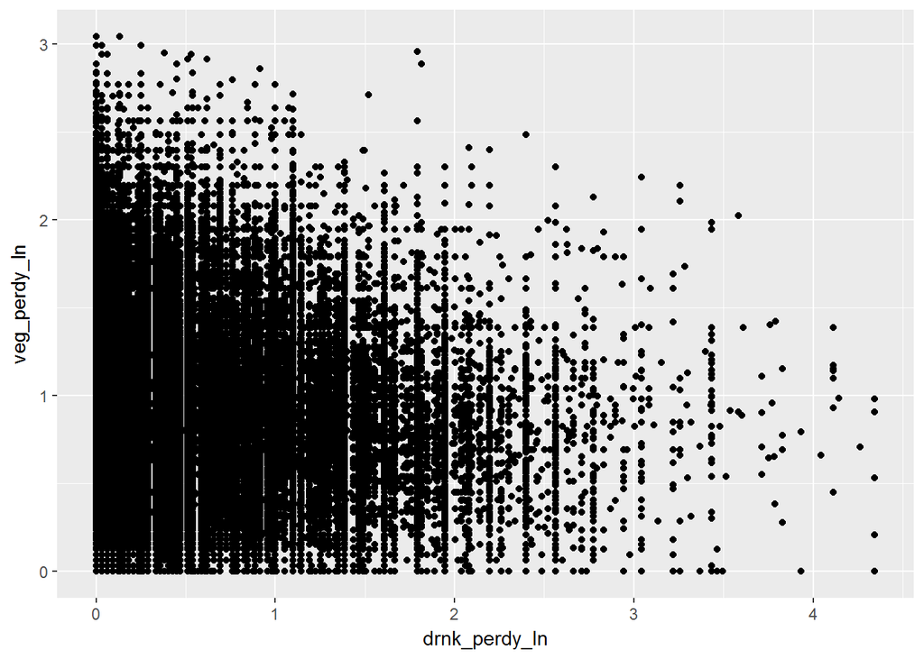

```r
brfss2013 %>%
  ggplot(aes(x = drnk_perdy_ln, y =veg_perdy_ln )) + geom_point()
```

There seem to be a relation between drinking and eating less vegetables. Let’s see more about alcohol, smoking and vegetables in a table

```r
brfss2013 %>%
  filter(!is.na(veg_perdy)) %>%
  group_by(rsk_drnk, smoker) %>%
  summarise(average_veggy_perday = mean(veg_perdy), std_slpt_hrs = sd(veg_perdy))
```

```
## # A tibble: 9 x 4
## # Groups:   rsk_drnk [?]
##   rsk_drnk smoker average_veggy_perday std_slpt_hrs
##      <chr>  <chr>                <dbl>        <dbl>
## 1       No     No             1.683714     1.145965
## 2       No    Yes             1.429287     1.075312
## 3       No   <NA>             1.690813     1.211319
## 4      Yes     No             1.609073     1.095567
## 5      Yes    Yes             1.426453     1.125183
## 6      Yes   <NA>             1.590399     1.148391
## 7     <NA>     No             1.601946     1.104686
## 8     <NA>    Yes             1.330552     1.113117
## 9     <NA>   <NA>             1.673307     1.276233
```

The avarage amount of vegetables consumed by smokers and drinkers is lower then the general avarage 1.64. We now define a new variable, identifying as bad habit eating vegetables less then once a day.

```r
brfss2013 <- brfss2013 %>%
  mutate(noveg = ifelse(veg_perdy < 1, "Yes", "No"))
brfss2013 %>%
  group_by(noveg) %>%
  summarise(count = n())
```

```
## # A tibble: 3 x 2
##   noveg  count
##   <chr>  <int>
## 1    No 320960
## 2   Yes 125982
## 3  <NA>  44833
```

## Physical activity

The variable `exerany` is all we ar going to use. “No” there will be seen as a bad habit.

```r
brfss2013 %>%
  group_by(exerany2) %>%
  summarise(count = n())
```

```
## # A tibble: 3 x 2
##   exerany2  count
##     <fctr>  <int>
## 1      Yes 332464
## 2       No 125282
## 3     <NA>  34029
```

```r
brfss2013 %>%
#  filter(!is.na(drnk_perdy)) %>%
  group_by( noveg,rsk_drnk) %>%
  summarise( n = n()) %>%
  mutate(freq = n/sum(n))
```

```
## # A tibble: 9 x 4
## # Groups:   noveg [3]
##   noveg rsk_drnk      n       freq
##   <chr>    <chr>  <int>      <dbl>
## 1    No       No 306615 0.95530596
## 2    No      Yes   9779 0.03046797
## 3    No     <NA>   4566 0.01422607
## 4   Yes       No 119537 0.94884190
## 5   Yes      Yes   4336 0.03441762
## 6   Yes     <NA>   2109 0.01674049
## 7  <NA>       No  26680 0.59509736
## 8  <NA>      Yes    951 0.02121205
## 9  <NA>     <NA>  17202 0.38369059
```

```r
tablegrph <-  brfss2013 %>%
  filter(!is.na(rsk_drnk) & !is.na(smoker)) %>%
  select(rsk_drnk, smoker) %>%
  group_by(rsk_drnk, smoker) %>%
  summarise(count = n()) %>%
  mutate(freq = count/sum(count))
p1 <- tablegrph %>%
  ggplot(aes(y = freq, x = rsk_drnk, fill = smoker)) +
  geom_bar(stat = "identity" ) +
  labs(x = "Risky drinker", fill = "Smoker", y = "Proportion")
```

```r
tablegrph <-  brfss2013 %>%
  filter(!is.na(rsk_drnk) & !is.na(noveg)) %>%
  select(rsk_drnk, noveg) %>%
  group_by(rsk_drnk, noveg) %>%
  summarise(count = n()) %>%
  mutate(freq = count/sum(count))
p2 <- tablegrph %>%
  ggplot(aes(y = freq, x = rsk_drnk, fill = noveg)) +
  geom_bar(stat = "identity" )  +
  labs(x = "Risky drinker", fill = "Scarce veggies", y = "Proportion")
```

```r
tablegrph <-  brfss2013 %>%
  filter(!is.na(exerany2) & !is.na(noveg)) %>%
  select(exerany2, noveg) %>%
  group_by(exerany2, noveg) %>%
  summarise(count = n()) %>%
  mutate(freq = count/sum(count))
p3 <- tablegrph %>%
  ggplot(aes(y = freq, x = exerany2, fill = noveg)) +
  geom_bar(stat = "identity" )  +
  labs(x = "Does exercise", fill = "Scarce veggies", y = "Proportion")
```

```r
tablegrph <-  brfss2013 %>%
  filter(!is.na(exerany2) & !is.na(smoker)) %>%
  select(exerany2, smoker) %>%
  group_by(exerany2, smoker) %>%
  summarise(count = n()) %>%
  mutate(freq = count/sum(count))
p4 <- tablegrph %>%
  ggplot(aes(y = freq, x = exerany2, fill = smoker)) +
  geom_bar(stat = "identity" )  +
  labs(x = "Does exercise", fill = "Smoker", y = "Proportion")
```

```r
tablegrph <-  brfss2013 %>%
  filter(!is.na(exerany2) & !is.na(rsk_drnk)) %>%
  select(exerany2, rsk_drnk) %>%
  group_by(rsk_drnk, exerany2) %>%
  summarise(count = n()) %>%
  mutate(freq = count/sum(count))
p5 <- tablegrph %>%
  ggplot(aes(y = freq, x = rsk_drnk, fill = exerany2)) +
  geom_bar(stat = "identity" )  +
  labs(fill = "Does exercise", x = "Risky Drinker", y = "Proportion")
```

```r
tablegrph <-  brfss2013 %>%
  filter(!is.na(noveg) & !is.na(smoker)) %>%
  select(noveg, smoker) %>%
  group_by(noveg, smoker) %>%
  summarise(count = n()) %>%
  mutate(freq = count/sum(count))
p6 <- tablegrph %>%
  ggplot(aes(y = freq, x = noveg, fill = smoker)) +
  geom_bar(stat = "identity" )  +
  labs(fill = "Smoker", x = "Scarce veggies", y = "Proportion")
```

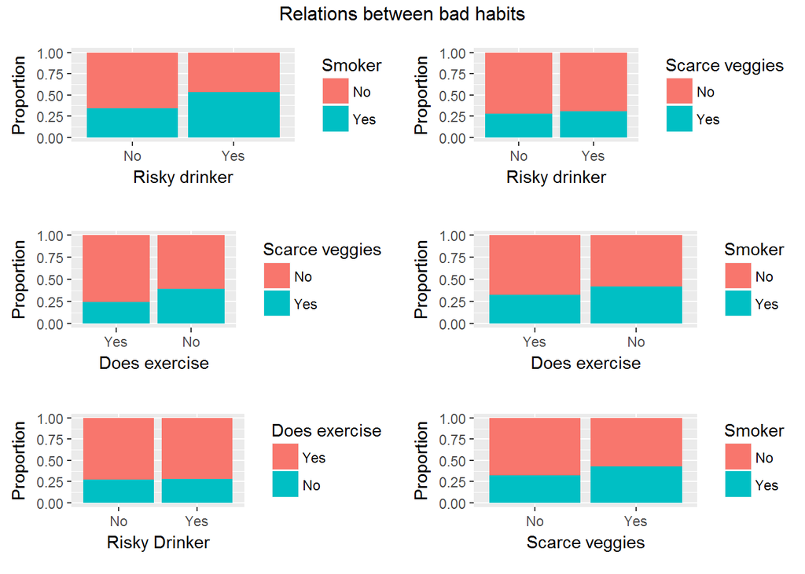

```r
gplots = list(p1, p2, p3, p4, p5, p6)
margin = theme(plot.margin = unit(c(0.5,0.25,0.5,0.25), "cm"))
gplots <- lapply(gplots, "+", margin)
grid.arrange(grobs = gplots,
             ncol = 2, top = "Relations between bad habits")
```

The six plots above, give an intuitive idea of the correlation between the 4 bad habits we are analyzing. In particular it seems that risky drinkers are more likely to be also smokers, and people who do not exercise enough are also unlikely to eat enough vegetables. Less marked, people who do not exercise or do not eat enough vegetables ar slightly more likely to be smokers. Drinking seems independent from doing exercise or eating vegetables.

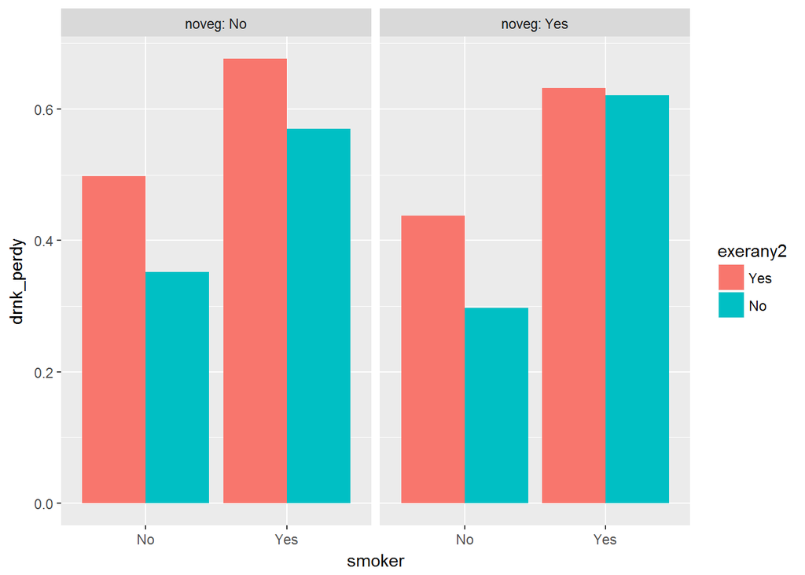

```r
brfss2013 %>%
  filter(!is.na(drnk_perdy) & ! is.na(smoker) & !is.na(exerany2) & !is.na(noveg)) %>%
  ggplot(aes(x = smoker, fill = exerany2, y = drnk_perdy)) +
  stat_summary(fun.y = "mean", geom = "bar", position = position_dodge()) +
  facet_grid(. ~ noveg, labeller = label_both)
```

This plot show the avarage number of drinks per day of the sample, conditioned on their habit on smoking, eating vegetables daily, doing exercise activity. It is interesting that people who do exercise, tend do drink more alcohol on avarage, as well people who eat daily vegetables. Smokers also tend to drink more.

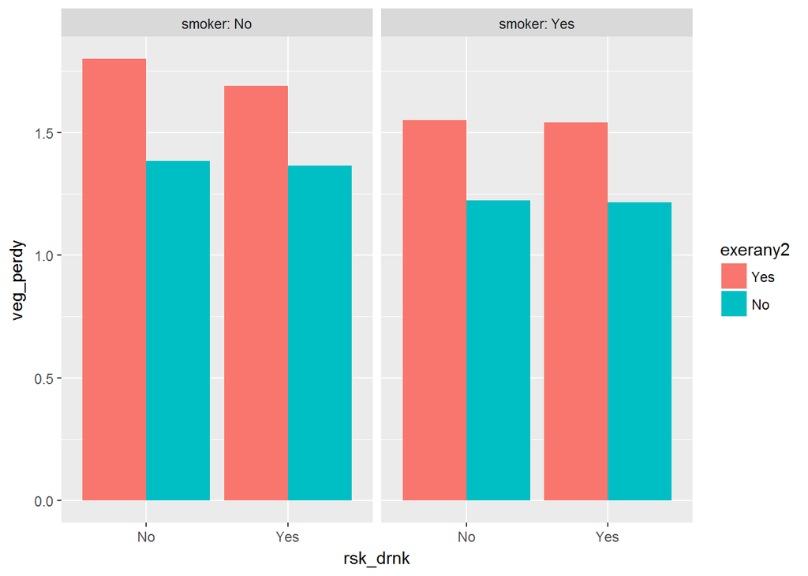

```r
brfss2013 %>%
  filter(!is.na(veg_perdy) & ! is.na(smoker) & !is.na(exerany2) & !is.na(rsk_drnk)) %>%
  ggplot(aes(x = rsk_drnk, fill = exerany2, y = veg_perdy)) +
  stat_summary(fun.y = "mean", geom = "bar", position = position_dodge()) +
  facet_grid(. ~ smoker, labeller = label_both)
```

From this graph we can see that smokers and people who do not exercise tend to eat less vegetables in avarage.

```r
brfss2013 %>%
#  filter(!is.na(drnk_perdy)) %>%
  group_by(smoker, rsk_drnk) %>%
  summarise(drinks = mean(drnk_perdy), n = n()) %>%
  mutate(freq = n/sum(n))
```

```
## # A tibble: 9 x 5
## # Groups:   smoker [3]
##   smoker rsk_drnk    drinks      n       freq
##    <chr>    <chr>     <dbl>  <int>      <dbl>
## 1     No       No 0.3007855 129890 0.94031201
## 2     No      Yes 4.0880233   4999 0.03618924
## 3     No     <NA>        NA   3246 0.02349875
## 4    Yes       No 0.2866427  68421 0.89256037
## 5    Yes      Yes 4.8630283   5726 0.07469637
## 6    Yes     <NA>        NA   2510 0.03274326
## 7   <NA>       No 0.1953473 254521 0.91890477
## 8   <NA>      Yes 4.1360099   4341 0.01567244
## 9   <NA>     <NA>        NA  18121 0.06542279
```

## Blood Pressure

bphigh4

```r
brfss2013<- brfss2013 %>%
  mutate(hgh_prssr = ifelse(is.na(bphigh4), NA,
                          ifelse(bphigh4 == "No", "No", "Yes")))
brfss2013 %>%
  group_by(hgh_prssr) %>%
  summarise(count = n())
```

```
## # A tibble: 3 x 2
##   hgh_prssr  count
##       <chr>  <int>
## 1        No 282687
## 2       Yes 207668
## 3      <NA>   1420
```

## Cholesterol

We will use the variable `toldhi2` to distinguish between people who had or have cholesterol problems and people without.

```r
brfss2013 %>%
  group_by(toldhi2) %>%
  summarise(count = n())
```

```
## # A tibble: 3 x 2
##   toldhi2  count
##    <fctr>  <int>
## 1     Yes 183501
## 2      No 236612
## 3    <NA>  71662
```

## Diabete

We use `diabete3` to define a new variable `dbt_related` which has value “Yes” is the interviewed has diabete, pre-diabetes or had dibetes during pregnancy.

```r
brfss2013<- brfss2013 %>%
  mutate(dbt_related = ifelse(is.na(diabete3), NA,
                          ifelse(diabete3 == "No", "No", "Yes")))
brfss2013 %>%
  group_by(dbt_related) %>%
  summarise(count = n())
```

```
## # A tibble: 3 x 2
##   dbt_related  count
##         <chr>  <int>
## 1          No 415374
## 2         Yes  75569
## 3        <NA>    832
```

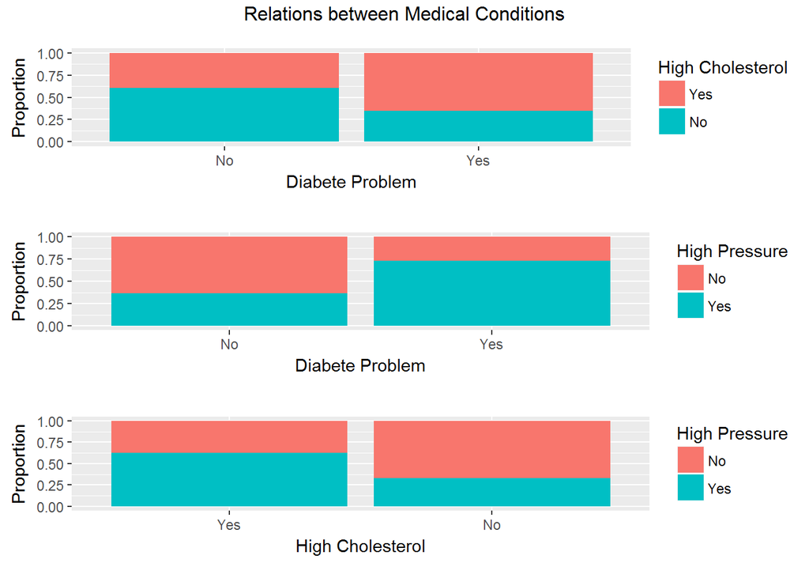

```r
tablegrph <-  brfss2013 %>%
  filter(!is.na(dbt_related) & !is.na(toldhi2)) %>%
  select(dbt_related, toldhi2) %>%
  group_by(dbt_related, toldhi2) %>%
  summarise(count = n()) %>%
  mutate(freq = count/sum(count))
p1 <- tablegrph %>%
  ggplot(aes(y = freq, x = dbt_related, fill = toldhi2)) +
  geom_bar(stat = "identity" )  +
  labs(fill = "High Cholesterol", x = "Diabete Problem", y = "Proportion")

tablegrph <-  brfss2013 %>%
  filter(!is.na(dbt_related) & !is.na(hgh_prssr)) %>%
  select(dbt_related, hgh_prssr) %>%
  group_by(dbt_related, hgh_prssr) %>%
  summarise(count = n()) %>%
  mutate(freq = count/sum(count))
p2 <- tablegrph %>%
  ggplot(aes(y = freq, x = dbt_related, fill = hgh_prssr)) +
  geom_bar(stat = "identity" )  +
  labs(fill = "High Pressure", x = "Diabete Problem", y = "Proportion")

tablegrph <-  brfss2013 %>%
  filter(!is.na(hgh_prssr) & !is.na(toldhi2)) %>%
  select(toldhi2, hgh_prssr) %>%
  group_by(toldhi2, hgh_prssr) %>%
  summarise(count = n()) %>%
  mutate(freq = count/sum(count))
p3 <- tablegrph %>%
  ggplot(aes(y = freq, x = toldhi2, fill = hgh_prssr)) +
  geom_bar(stat = "identity" )  +
  labs(fill = "High Pressure", x = "High Cholesterol", y = "Proportion")

gplots = list(p1, p2, p3)
margin = theme(plot.margin = unit(c(0.5,0.25,0.5,0.25), "cm"))
gplots <- lapply(gplots, "+", margin)
grid.arrange(grobs = gplots,
             ncol = 1, top = "Relations between Medical Conditions")
```

## Mental Health

As a metric on mental health we use the number of days in the past month when the interviewd had mental health problems, `menthlth`. However to, avoid inconsistent values (greater then 30) we clean it and save in `menthlth2`.

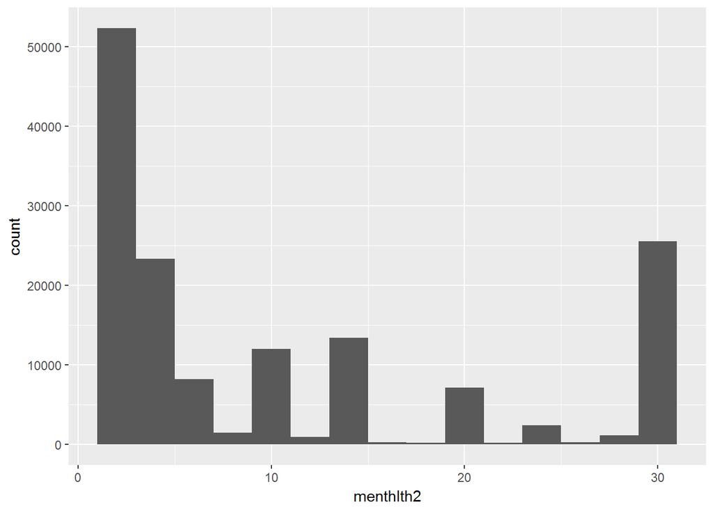

```r
brfss2013 <- brfss2013 %>%
  mutate(menthlth2 = ifelse(menthlth < 31, menthlth, NA))
brfss2013 %>%
  filter(menthlth2 > 0) %>%
  ggplot(aes(x = menthlth2)) +
  geom_histogram(binwidth = 2)
```

this is the sample distribution of the number of days of mental health in the last month, restricted to the samples with at least 1 day of mental health problems

We want to compare the avarage number of days of mental health problems with the subset of people having, diabetes, high cholesterol and high pressure problems.

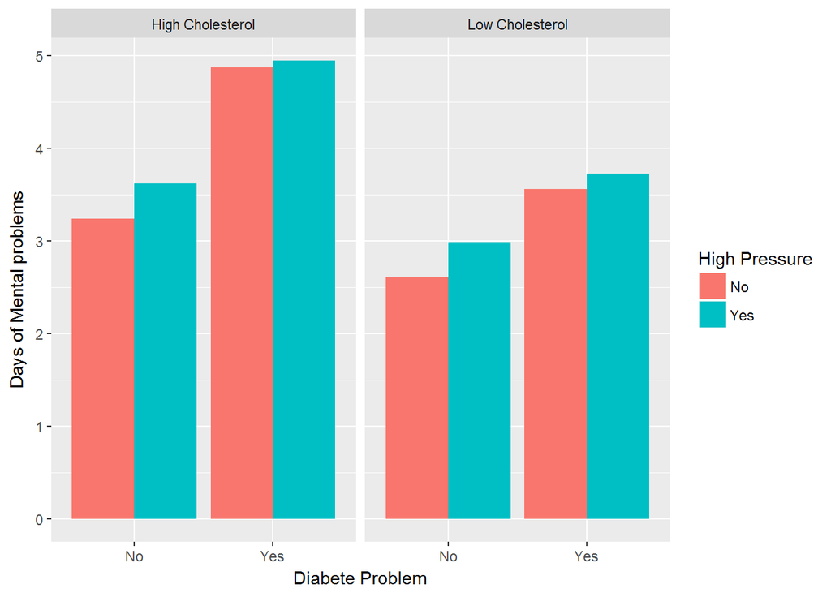

```r
brfss2013 %>%
  filter(!is.na(menthlth2) & !is.na(dbt_related) & !is.na(hgh_prssr) & !is.na(toldhi2)) %>%
  ggplot(aes(x = dbt_related, fill = hgh_prssr, y = menthlth2)) +
  stat_summary(fun.y = "mean", geom = "bar", position = position_dodge()) +
  facet_grid(. ~ toldhi2, labeller =
               labeller( toldhi2 = c(Yes = "High Cholesterol", No = "Low Cholesterol"))) +
  labs(x = "Diabete Problem", y = "Days of Mental problems", fill = "High Pressure")
```

```r
brfss2013 %>%
  filter(!is.na(menthlth2) & ! is.na(dbt_related) & !is.na(hgh_prssr) & !is.na(toldhi2)) %>%
  group_by(toldhi2, dbt_related, hgh_prssr) %>%
  summarise(mental_bad_days = mean(menthlth2), count = n()) %>%
  mutate(freq = count/sum(count))
```

```
## # A tibble: 8 x 6
## # Groups:   toldhi2, dbt_related [4]
##   toldhi2 dbt_related hgh_prssr mental_bad_days  count      freq
##    <fctr>       <chr>     <chr>           <dbl>  <int>     <dbl>
## 1     Yes          No        No        3.238189  58483 0.4362677
## 2     Yes          No       Yes        3.619227  75570 0.5637323
## 3     Yes         Yes        No        4.873766   8714 0.1923663
## 4     Yes         Yes       Yes        4.943337  36585 0.8076337
## 5      No          No        No        2.605936 146499 0.7032875
## 6      No          No       Yes        2.983982  61807 0.2967125
## 7      No         Yes        No        3.557038   9222 0.3796155
## 8      No         Yes       Yes        3.725433  15071 0.6203845
```

# Bad Habits vs Health

```r
numeric_yes_no <- function(yesno) {
  output <- ifelse(is.na(yesno), 0,
                   ifelse(yesno == "Yes", 1, 0))
  return(output)
}

compute_bad_habits <- function(drinker, smoker, noveg, exerc) {
  drinker <- numeric_yes_no(drinker)
  smoker <- numeric_yes_no(smoker)
  noveg <- numeric_yes_no(noveg)
  exerc <- numeric_yes_no(exerc)
  exerc <- abs(1 - exerc)
  output <- smoker + drinker + noveg + exerc
  return(output)
}


brfss2013 <- brfss2013 %>%
  mutate(badhbts = compute_bad_habits(drinker = rsk_drnk, smoker = smoker,
                                      noveg = noveg, exerc = exerany2))
```

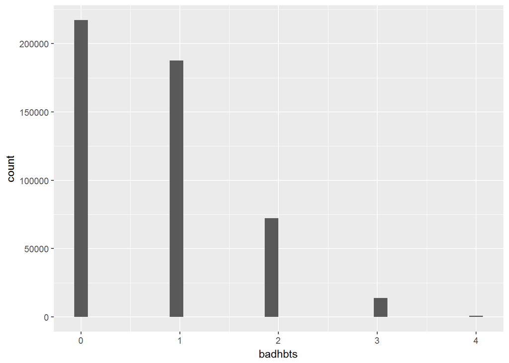

```r
brfss2013 %>%
  ggplot(aes(x = badhbts)) +
  geom_histogram()
```

```r
tablegraph <- brfss2013 %>%
  filter(!is.na(menthlth2)) %>%
  group_by(badhbts) %>%
  summarise(Days_mental_hlth_prblm = mean(menthlth2))
tablegraph
```

```
## # A tibble: 5 x 2
##   badhbts Days_mental_hlth_prblm
##     <dbl>                  <dbl>
## 1       0               2.275788
## 2       1               3.553298
## 3       2               5.404303
## 4       3               7.359621
## 5       4               8.092796
```

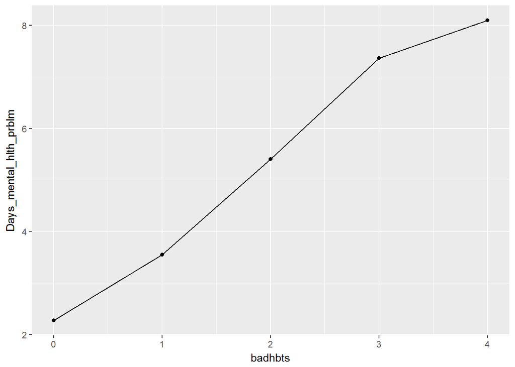

```r
tablegraph %>%
  ggplot(aes(x = badhbts, y = Days_mental_hlth_prblm)) +
  geom_point() +
  geom_line()
```

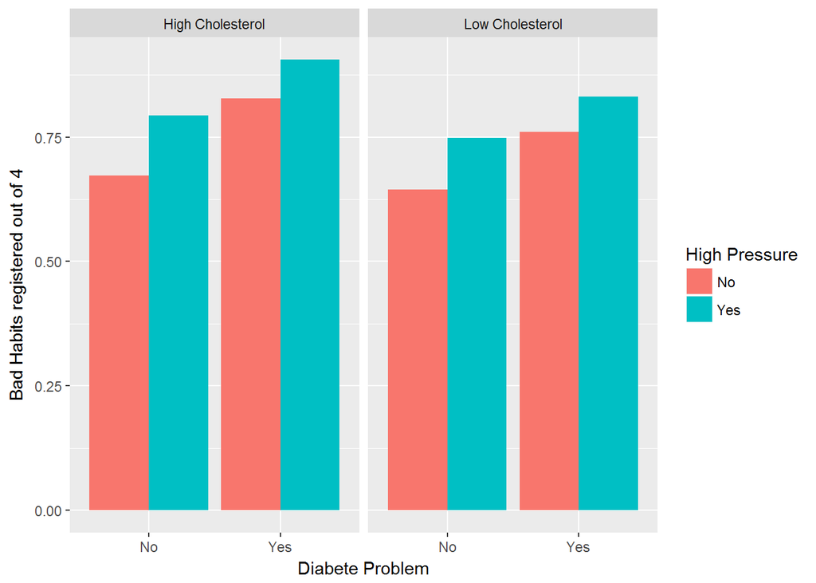

```r
brfss2013 %>%
  filter(!is.na(badhbts) & !is.na(dbt_related) & !is.na(hgh_prssr) & !is.na(toldhi2)) %>%
  ggplot(aes(x = dbt_related, fill = hgh_prssr, y = badhbts)) +
  stat_summary(fun.y = "mean", geom = "bar", position = position_dodge()) +
  facet_grid(. ~ toldhi2, labeller =
               labeller( toldhi2 = c(Yes = "High Cholesterol", No = "Low Cholesterol"))) +
  labs(x = "Diabete Problem", y = "Bad Habits registered out of 4", fill = "High Pressure")
```